# Tutorial 2a: Regularization for Linear Regression

Compiled 2024-10-27 11:57:46.805056

Complete this tutorial first.

# Objectives

- Apply K-fold cross-validation in R using **tidymodels**
- Apply regularized linear regression models using **tidymodels**

Subset selection for linear regression is illustrated in an optional exercise at the end of this tutorial. The second tutorial for Module 2 illustrates regularized logistic regression.

# Packages

Load packages:

```r
library(tidymodels)
library(tidyverse)
```

You might need to install these:

```r
# install.packages('glmnet')
# install.packages('leaps')
```

# Data

## Loading the data

Load the full credit card default data from a CSV file.

```r
col_spec <- cols(
  Income = col_double(),
  Limit = col_integer(),
  Rating = col_integer(),
  Cards = col_integer(),
  Age = col_integer(),
  Education = col_integer(),
  Gender = col_factor(levels = c("Male", "Female")),
  Student = col_factor(levels = c("No", "Yes")),
  Married = col_factor(levels = c("No", "Yes")),
  Ethnicity = col_factor(levels = c("Caucasian", "Asian", "African American")),
  Balance = col_double()
)
Credit <- read_csv("Credit.csv", col_types = col_spec)
```

Print the data to ensure it was loaded correctly.

```r
Credit
```

| Income | Limit | Rating | Cards | Age | Education | Gender | Student | Married | Ethnicity | Balance |
| --- | --- | --- | --- | --- | --- | --- | --- | --- | --- | --- |
| 14.891 | 3606 | 283 | 2 | 34 | 11 | Male | No | Yes | Caucasian | 333 |
| 106.025 | 6645 | 483 | 3 | 82 | 15 | Female | Yes | Yes | Asian | 903 |
| 104.593 | 7075 | 514 | 4 | 71 | 11 | Male | No | No | Asian | 580 |
| 148.924 | 9504 | 681 | 3 | 36 | 11 | Female | No | No | Asian | 964 |
| 55.882 | 4897 | 357 | 2 | 68 | 16 | Male | No | Yes | Caucasian | 331 |
| 80.180 | 8047 | 569 | 4 | 77 | 10 | Male | No | No | Caucasian | 1151 |
| 20.996 | 3388 | 259 | 2 | 37 | 12 | Female | No | No | African American | 203 |
| 71.408 | 7114 | 512 | 2 | 87 | 9 | Male | No | No | Asian | 872 |
| 15.125 | 3300 | 266 | 5 | 66 | 13 | Female | No | No | Caucasian | 279 |
| 71.061 | 6819 | 491 | 3 | 41 | 19 | Female | Yes | Yes | African American | 1350 |

[output cut: 390 more lines]

The goal is to predict the (continuous) credit card `Balance` variable. This is the average monthly credit card debt. The data are cross sectional; each row represents a different person.

## Model assessment

We need to specify the goal of the modelling effort so that we can choose an appropriate assessment strategy. Our goal is to select between candidate models for predicting `Balance`. The candidate models will be variants of linear regression, such as lasso- and ridge-penalized linear regression.

We need an assessment set, which we will use to choose between the candidate models (ridge and lasso) and get a rough estimate of expected test error. But we also need to tune the `penalty` hyper-parameter for these models first. For that, we will use 10-fold cross-validation. We can create both the initial train-test split and the cross-validation folds now.

Start with an analysis/assessment split, using 75% of the data for analysis, and the remaining 25% for assessment:

```r
set.seed(86045)
Credit_split <- initial_split(Credit, prop = .75)
```

Create the training (analysis) and testing (assessment) sets:

```r
Credit_train <- training(Credit_split)
Credit_test <- testing(Credit_split)
```

Models will be tuned against the training set only, using 10-fold cross-validation. Create these folds:

```r
set.seed(1185)
cv_folds <- vfold_cv(Credit_train, v = 10)
```

This produces a set of resamples, one for each fold:

```r
cv_folds
```

```
## #  10-fold cross-validation
## # A tibble: 10 × 2
##    splits           id
##    <list>           <chr>
##  1 <split [270/30]> Fold01
##  2 <split [270/30]> Fold02
##  3 <split [270/30]> Fold03
##  4 <split [270/30]> Fold04
##  5 <split [270/30]> Fold05
##  6 <split [270/30]> Fold06
##  7 <split [270/30]> Fold07
##  8 <split [270/30]> Fold08
##  9 <split [270/30]> Fold09
## 10 <split [270/30]> Fold10
```

We are now ready to define the models. We will then tune the models using cross-validation (CV).

## Exploring the data

Please perform exploratory data analysis yourself on the analysis set before proceeding. Note down any interesting findings. You may find the **skimr** package useful. If you do use this package, do not forget to add the code for loading the package to the top of your notebook.

## k-fold cross-validation and data exploration

# Modelling

The state-of-the art implementation of lasso- and ridge-regularized generalized linear regression models is undoubtedly the **glmnet** package. Its functionality is available in **tidymodels** through the `"glmnet"` computational engine. We will apply lasso- and ridge-regularized linear regression models via **tidymodels**.

## Pre-processing recipe

The first step is to set up a pre-processing recipe for handling the data *within* each CV iteration. Here we need to take care to (1) convert the factors to a numeric representation, for example using dummy variables; and (2) to normalize the columns to have mean zero and standard deviation one. The latter is required to ensure the effect of the penalty term on model fit and predictions is unaffected by differences in measurement scales across features.

Regularization is useful when there are many predictor variables. The data for this tutorial has just 10 predictor variables, so the regression model specified next includes all of these predictor variables, as well as all pairwise interactions between these predictors.

```r
linear_reg_recipe <-
  recipe(Balance ~ ., data = Credit_train) |>
  step_dummy(all_nominal_predictors()) |>
  # interact every predictor with every other predictor
  # the : operator specifies pairwise interactions in R formulas
  step_interact(~ all_predictors():all_predictors()) |>
  # remove any resulting variables that have only one value
  # and thus zero variance ("zv")
  step_zv(all_predictors()) |>
  # normalize the predictors to have mean 0 and SD 1
  step_normalize(all_predictors())
```

Review the recipe:

```r
linear_reg_recipe
```

```
##
## ── Recipe ──────────────────────────────────────────────────────────────────────
##
## ── Inputs
## Number of variables by role
## outcome:    1
## predictor: 10
##
## ── Operations
## • Dummy variables from: all_nominal_predictors()
## • Interactions with: all_predictors():all_predictors()
## • Zero variance filter on: all_predictors()
## • Centering and scaling for: all_predictors()
```

Let’s see what this recipe does when applied to the training data, in order to verify it is specified correctly:

```r
Credit_train_baked <-
  linear_reg_recipe |>
  prep(Credit_train) |>
  bake(Credit_train)
Credit_train_baked
```

| Income | Limit | Rating | Cards | Age | Education | Balance | Gender_Female | Student_Yes | Married_Yes | Ethnicity_Asian | Ethnicity_African.American | Income_x_Limit | Income_x_Rating | Income_x_Cards | Income_x_Age | Income_x_Education | Income_x_Gender_Female | Income_x_Student_Yes | Income_x_Married_Yes | Income_x_Ethnicity_Asian | Income_x_Ethnicity_African.American | Limit_x_Rating | Limit_x_Cards | Limit_x_Age | Limit_x_Education | Limit_x_Gender_Female | Limit_x_Student_Yes | Limit_x_Married_Yes | Limit_x_Ethnicity_Asian | … |
| --- | --- | --- | --- | --- | --- | --- | --- | --- | --- | --- | --- | --- | --- | --- | --- | --- | --- | --- | --- | --- | --- | --- | --- | --- | --- | --- | --- | --- | --- | --- |
| -0.439213478 | 0.206341077 | 0.230102108 | 0.05063072 | -1.750075162 | 0.4972275 | 799 | -0.9655908 | -0.3265798 | -1.321534 | -0.5968874 | -0.5866349 | -0.32269146 | -0.32388733 | -0.328329262 | -0.760725131 | -0.30899270 | -0.6508109876 | -0.2445148 | -0.789347002 | -0.43575322 | -0.427812449 | 0.0001181495 | 0.149886288 | -0.797954660 | 0.421584101 | -0.80673180 | -0.2952946 | -1.022788826 | -0.517548142 | … |
| -0.703919981 | -0.981708306 | -1.021765202 | 0.05063072 | 0.110882033 | 0.4972275 | 0 | 1.0321833 | -0.3265798 | 0.754174 | -0.5968874 | 1.6989556 | -0.58823144 | -0.59758077 | -0.533564900 | -0.592593555 | -0.58672495 | -0.0660185598 | -0.2445148 | -0.245452055 | -0.43575322 | 0.276241782 | -0.7921731742 | -0.623795266 | -0.732580068 | -0.734839856 | 0.05564280 | -0.2952946 | -0.185846497 | -0.517548142 | … |
| -0.249634691 | -0.517413145 | -0.526102003 | 0.77392675 | -1.168526038 | -1.3673755 | 187 | -0.9655908 | -0.3265798 | 0.754174 | 1.6697735 | -0.5866349 | -0.38672455 | -0.38172265 | 0.081066537 | -0.539841651 | -0.53620687 | -0.6508109876 | -0.2445148 | 0.194937971 | 0.90875815 | -0.427812449 | -0.5452847702 | 0.013250717 | -0.834552757 | -0.883214367 | -0.80673180 | -0.2952946 | 0.174784495 | 0.978073884 | … |
| -0.612426153 | -1.129360995 | -1.231468863 | -0.67266530 | 1.157670455 | 0.4972275 | 0 | -0.9655908 | -0.3265798 | -1.321534 | 1.6697735 | -0.5866349 | -0.58776255 | -0.60168761 | -0.631274502 | -0.341036164 | -0.49072887 | -0.6508109876 | -0.2445148 | -0.789347002 | 0.42835098 | -0.427812449 | -0.8619302935 | -0.921799763 | -0.618758234 | -0.878562086 | -0.80673180 | -0.2952946 | -1.022788826 | 0.384461377 | … |
| -0.940921393 | -1.087113549 | -1.104375735 | 0.05063072 | 0.925050805 | -0.7458412 | 0 | -0.9655908 | -0.3265798 | 0.754174 | -0.5968874 | -0.5866349 | -0.64894674 | -0.66309587 | -0.717319872 | -0.725666273 | -0.92605567 | -0.6508109876 | -0.2445148 | -0.475204284 | -0.43575322 | -0.427812449 | -0.8312342344 | -0.692437271 | -0.628605282 | -1.089770073 | -0.80673180 | -0.2952946 | -0.267717687 | -0.517548142 | … |
| -0.415390452 | -0.163644130 | -0.284625060 | -1.39596133 | -1.459300600 | 0.1864603 | 450 | 1.0321833 | -0.3265798 | -1.321534 | -0.5968874 | 1.6989556 | -0.37728970 | -0.39923445 | -0.748999523 | -0.688888811 | -0.34342353 | 0.2347176924 | -0.2445148 | -0.789347002 | -0.43575322 | 0.638309793 | -0.3479091051 | -0.914018483 | -0.794831855 | -0.061560745 | 0.71036443 | -0.2952946 | -1.022788826 | -0.517548142 | … |
| -0.300408739 | -0.663358866 | -0.704032382 | 0.05063072 | 0.110882033 | 1.1187618 | 47 | 1.0321833 | -0.3265798 | 0.754174 | 1.6697735 | -0.5866349 | -0.43266159 | -0.43392233 | -0.220709393 | -0.251467446 | -0.02842002 | 0.3545638981 | -0.2445148 | 0.145716953 | 0.84152333 | -0.427812449 | -0.6375632746 | -0.416479734 | -0.484378426 | -0.243802748 | 0.31042753 | -0.2952946 | 0.061424385 | 0.836501026 | … |
| 0.523203286 | 0.150864633 | 0.236456764 | 1.49722277 | -0.412512178 | -1.6781427 | 411 | -0.9655908 | -0.3265798 | 0.754174 | -0.5968874 | 1.6989556 | 0.11374486 | 0.16337615 | 1.342153422 | 0.206117380 | -0.17476423 | -0.6508109876 | -0.2445148 | 0.944137084 | -0.43575322 | 1.816126038 | -0.0228353029 | 1.073264848 | -0.121636997 | -0.636338898 | -0.80673180 | -0.2952946 | 0.693854470 | -0.517548142 | … |
| -0.684314161 | -0.918977250 | -0.996346576 | -1.39596133 | 0.866895893 | 1.4295289 | 0 | 1.0321833 | -0.3265798 | -1.321534 | -0.5968874 | 1.6989556 | -0.57616284 | -0.58965517 | -0.818501315 | -0.464061945 | -0.44430732 | -0.0455832826 | -0.2445148 | -0.789347002 | -0.43575322 | 0.300844603 | -0.7723554231 | -1.077981168 | -0.480917075 | -0.451798446 | 0.10584837 | -0.2952946 | -1.022788826 | -0.517548142 | … |
| -0.571678444 | 0.285715066 | 0.306357985 | -1.39596133 | -1.284835863 | -1.3673755 | 1352 | -0.9655908 | 3.0518319 | -1.321534 | -0.5968874 | -0.5866349 | -0.37408501 | -0.38008034 | -0.789391260 | -0.727580389 | -0.73894145 | -0.6508109876 | 1.0123317 | -0.789347002 | -0.43575322 | -0.427812449 | 0.0692202469 | -0.816474580 | -0.514217257 | -0.414164822 | -0.80673180 | 3.0353918 | -1.022788826 | -0.517548142 | … |

[output cut: 290 more lines]

There are 66 columns (including the target variable), as the factor columns (categorical variables) have been replaced by dummy variables and pairwise interactions have been added. The features (i.e., predictors) are also normalized to have mean zero and standard deviation of one:

```r
Credit_train_baked |>
  summarise(across(everything(), list(m = mean, s = sd))) |>
  mutate(across(everything(), ~ round(.x, 2)))
```

```
## # A tibble: 1 × 132
##   Income_m Income_s Limit_m Limit_s Rating_m Rating_s Cards_m Cards_s Age_m
##      <dbl>    <dbl>   <dbl>   <dbl>    <dbl>    <dbl>   <dbl>   <dbl> <dbl>
## 1        0        1       0       1        0        1       0       1     0
## # ℹ 123 more variables: Age_s <dbl>, Education_m <dbl>, Education_s <dbl>,
## #   Balance_m <dbl>, Balance_s <dbl>, Gender_Female_m <dbl>,
## #   Gender_Female_s <dbl>, Student_Yes_m <dbl>, Student_Yes_s <dbl>,
## #   Married_Yes_m <dbl>, Married_Yes_s <dbl>, Ethnicity_Asian_m <dbl>,
## #   Ethnicity_Asian_s <dbl>, Ethnicity_African.American_m <dbl>,
## #   Ethnicity_African.American_s <dbl>, Income_x_Limit_m <dbl>,
## #   Income_x_Limit_s <dbl>, Income_x_Rating_m <dbl>, Income_x_Rating_s <dbl>, …
```

During CV, for each CV fold, the recipe will be prepared on the training subset for the fold, then baked on (applied to) both the training and validation subsets for the fold. Predictors in the training subset will then have mean 0 and SD 1, but predictors in the validation subset *will not*.

This point can be illustrated by performing the *prepare* and *bake* steps manually for one of the CV folds:

```r
linear_reg_recipe |>
  # prepping from the training subset for CV fold 1
  prep(training(cv_folds$splits[[1]])) |>
  # baking the training subset for CV fold 1
  bake(training(cv_folds$splits[[1]])) |>
  summarise(across(everything(), list(m = mean, s = sd))) |>
  mutate(across(everything(), ~ round(.x, 2)))
```

```
## # A tibble: 1 × 132
##   Income_m Income_s Limit_m Limit_s Rating_m Rating_s Cards_m Cards_s Age_m
##      <dbl>    <dbl>   <dbl>   <dbl>    <dbl>    <dbl>   <dbl>   <dbl> <dbl>
## 1        0        1       0       1        0        1       0       1     0
## # ℹ 123 more variables: Age_s <dbl>, Education_m <dbl>, Education_s <dbl>,
## #   Balance_m <dbl>, Balance_s <dbl>, Gender_Female_m <dbl>,
## #   Gender_Female_s <dbl>, Student_Yes_m <dbl>, Student_Yes_s <dbl>,
## #   Married_Yes_m <dbl>, Married_Yes_s <dbl>, Ethnicity_Asian_m <dbl>,
## #   Ethnicity_Asian_s <dbl>, Ethnicity_African.American_m <dbl>,
## #   Ethnicity_African.American_s <dbl>, Income_x_Limit_m <dbl>,
## #   Income_x_Limit_s <dbl>, Income_x_Rating_m <dbl>, Income_x_Rating_s <dbl>, …
```

```r
linear_reg_recipe |>
  # prepping from the training set for CV fold 1
  prep(training(cv_folds$splits[[1]])) |>
  # baking the *validation* set for CV fold 1
  bake(testing(cv_folds$splits[[1]])) |>
  summarise(across(everything(), list(m = mean, s = sd))) |>
  mutate(across(everything(), ~ round(.x, 2)))
```

```
## # A tibble: 1 × 132
##   Income_m Income_s Limit_m Limit_s Rating_m Rating_s Cards_m Cards_s Age_m
##      <dbl>    <dbl>   <dbl>   <dbl>    <dbl>    <dbl>   <dbl>   <dbl> <dbl>
## 1     0.03      1.2   -0.11     1.3    -0.08      1.3    0.58    1.07  0.14
## # ℹ 123 more variables: Age_s <dbl>, Education_m <dbl>, Education_s <dbl>,
## #   Balance_m <dbl>, Balance_s <dbl>, Gender_Female_m <dbl>,
## #   Gender_Female_s <dbl>, Student_Yes_m <dbl>, Student_Yes_s <dbl>,
## #   Married_Yes_m <dbl>, Married_Yes_s <dbl>, Ethnicity_Asian_m <dbl>,
## #   Ethnicity_Asian_s <dbl>, Ethnicity_African.American_m <dbl>,
## #   Ethnicity_African.American_s <dbl>, Income_x_Limit_m <dbl>,
## #   Income_x_Limit_s <dbl>, Income_x_Rating_m <dbl>, Income_x_Rating_s <dbl>, …
```

## Ridge and lasso linear regression models

We can start by setting up workflows for a ridge- and a lasso-penalized model. The steps involved closely mirror each other, so we will build the models concurrently.

In the underlying **glmnet** package, there is parameter called `alpha` which takes values between 0 and 1. When `alpha = 1`, we obtain the lasso penalty, and when `alpha = 0`, we get the ridge penalty. Values in between 0 and 1 provides a mixture of these two, and is called the *elastic net* penalty.

We have to take care to set this `alpha` correctly in advance to obtain the desired models. In the **parsnip** package, the `alpha` parameter is named `mixture`. Hence, we need to define the ridge and lasso models by setting the `mixture` parameter to the desired value for `alpha`.

```r
# mixture = 0 means ridge
ridge_linear_reg <-
  linear_reg(penalty = tune(), mixture = 0) |>
  set_engine("glmnet")
# mixture = 1 means lasso
lasso_linear_reg <-
  linear_reg(penalty = tune(), mixture = 1) |>
  set_engine("glmnet")
```

Here `penalty` refers to the $\lambda$ penalty parameter, which will be tuned.

Verify the models look correct:

```r
ridge_linear_reg |> translate()
```

```
## Linear Regression Model Specification (regression)
##
## Main Arguments:
##   penalty = tune()
##   mixture = 0
##
## Computational engine: glmnet
##
## Model fit template:
## glmnet::glmnet(x = missing_arg(), y = missing_arg(), weights = missing_arg(),
##     alpha = 0, family = "gaussian")
```

```r
lasso_linear_reg |> translate()
```

```
## Linear Regression Model Specification (regression)
##
## Main Arguments:
##   penalty = tune()
##   mixture = 1
##
## Computational engine: glmnet
##
## Model fit template:
## glmnet::glmnet(x = missing_arg(), y = missing_arg(), weights = missing_arg(),
##     alpha = 1, family = "gaussian")
```

## Combine the models and recipe into workflows

Combine the data preparation and model specifications into workflows:

```r
ridge_wf <-
  workflow() |>
  add_recipe(linear_reg_recipe) |>
  add_model(ridge_linear_reg)
lasso_wf <-
  workflow() |>
  add_recipe(linear_reg_recipe) |>
  add_model(lasso_linear_reg)
```

## Tuning grids

We need to choose a strategy for tuning the lasso and ridge penalties. Given we only have one hyperparameter to tune for each, we can specify a strategy of searching over a predefined grid of values.

We will set up two different grids for values of $\lambda$ (`penalty`) to search over, one for the lasso and one for ridge regularization. We define separate tuning grids because the scale of the optimal $\lambda$ could be very different for the lasso and ridge models, and finding the appropriate ranges for the grid often entails trial-and-error.

The values given here will work well for this problem:

```r
grid_lasso <-
  grid_regular(penalty(c(-2, 2), trans = log10_trans()),
    levels = 50
  )
grid_ridge <-
  grid_regular(penalty(c(0, 4), trans = log10_trans()),
    levels = 50
  )
```

The grid values are equally spaced on a *logarithmic* scale (using base 10, because that will be convenient in our plots).

**Logarithmic scale?**

For example, `grid_lasso` contains 50 points ranging from $10^{-2}$ to $10^2$. The 50 points in the grid are arranged such that the exponent $q$ in $10^q$ are spaced equally between -2 to 2, as shown by the equal spacing along the x-axis below.

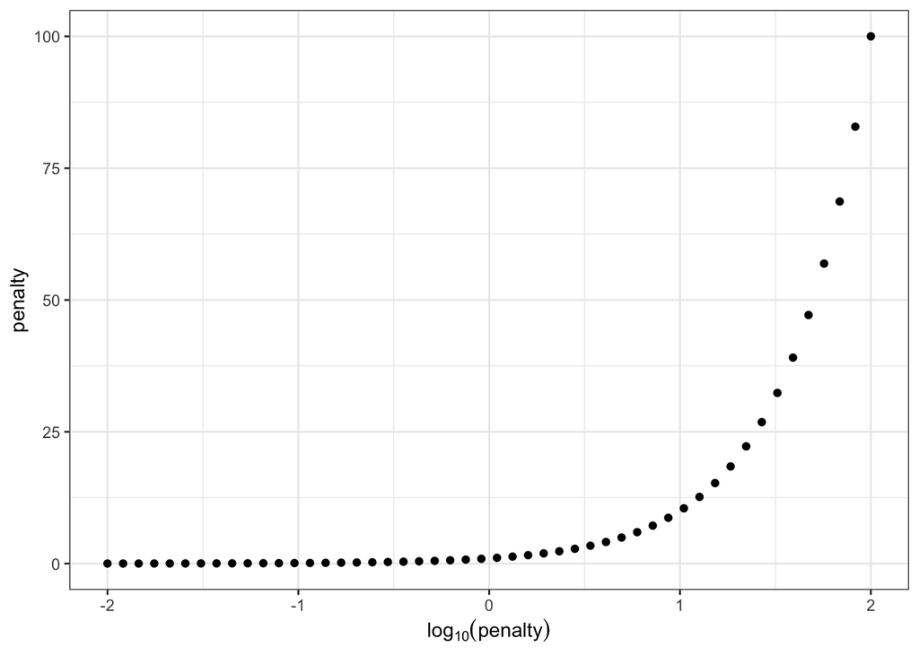

```r
grid_lasso |>
  ggplot(aes(x = log10(penalty), y = penalty)) +
  geom_point() +
  labs(x = expression(log[10](penalty)), y = "penalty") +
  theme_bw()
```

## Tune lasso-penalized linear regression

The main metrics for model fit is RMSE (`rmse`). Other metrics are $R^2$ (based on sums-of-squares, `rsq_trad`), and mean absolute error (`mae`). We can now tune the lasso model using `tune_grid()`:

```r
lasso_tune <-
  lasso_wf |>
  tune_grid(
    resamples = cv_folds,
    grid = grid_lasso,
    metrics = metric_set(rmse, rsq_trad, mae)
  )
```

Now we collect the tuning metrics and create a plot of showing RMSE, evaluated over the 10 CV validation folds.

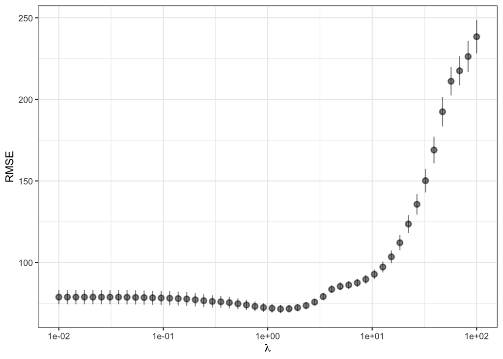

```r
lasso_tune_metrics <-
  lasso_tune |>
  collect_metrics()
lasso_tune_metrics |>
  filter(.metric == "rmse") |>
  ggplot(aes(
    x = penalty, y = mean,
    ymin = mean - std_err, ymax = mean + std_err
  )) +
  geom_pointrange(alpha = 0.5) +
  scale_x_log10() +
  labs(y = "RMSE", x = expression(lambda)) +
  theme_bw()
```

The plot shows one-standard-error bars around each RMSE estimate. This allows the plot to show uncertainty in the measurement of RMSE across the 10 folds. Recall that each model is trained and validated 10 times. The point is thus centered on the average RMSE across folds, and the error bar represents sampling uncertainty in the mean estimate. The magnitude of the errors is low relative to differences across means. From this, we infer that, for the values of $\lambda$ shown, model performance is relatively stable between CV folds. Wider error bounds would indicate that model fit is highly variable across folds.

We know that the tuning grid we chose is suitable for model selection because there is a clear dip in test error in the interior of the hyperparameter grid. Estimated test error is very high when the penalty is high (large $\lambda$), suggesting models that underfit the data. Estimated test error is then lower for lower penalties (intermediate values $\lambda$), suggesting models that can predict better due to their higher flexibility. And estimated test error is higher again when the penalty is very low (small $\lambda$), suggesting models that overfit the data and thus generalize poorly. Moreover, prediction error is stable for very low values of $\lambda$, suggesting the penalty hyperparameter is not constraining the coefficients for those values—it is effectively zero and the coefficients are equal to their OLS counterparts. We can deduce from the results that unregularized (i.e., standard OLS) linear regression would already perform well for this problem, because low values of $\lambda$ are almost as good as the best RMSE shown in the plot.

We can create similar plots for the other metrics.

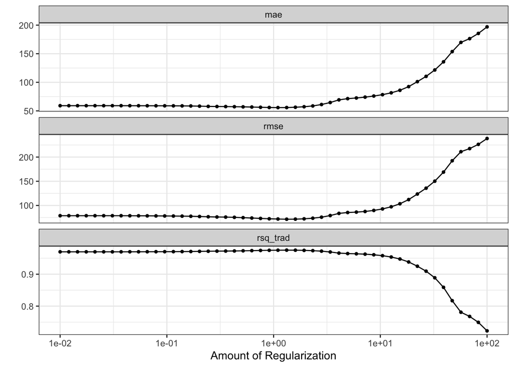

```r
lasso_tune |>
  autoplot() +
  theme_bw()
```

Obtain the 5 best values of $\lambda$ according to RMSE:

```r
lasso_tune |>
  show_best(metric = "rmse")
```

```
## # A tibble: 5 × 7
##   penalty .metric .estimator  mean     n std_err .config
##     <dbl> <chr>   <chr>      <dbl> <int>   <dbl> <chr>
## 1   1.33  rmse    standard    71.5    10    2.49 Preprocessor1_Model27
## 2   1.60  rmse    standard    71.7    10    2.34 Preprocessor1_Model28
## 3   1.10  rmse    standard    71.9    10    2.63 Preprocessor1_Model26
## 4   1.93  rmse    standard    72.3    10    2.23 Preprocessor1_Model29
## 5   0.910 rmse    standard    72.4    10    2.77 Preprocessor1_Model25
```

Note that estimated RMSE for the best fitting model is 71.5 with a standard error of 2.5; whereas the estimated RMSE for the second best model is 71.7 with a standard error of 2.3. There is a good chance that the second best model will actually predict better, but due to sampling uncertainty in the creation of the CV folds, a different model performed better. Put differently, the results are consistent with more than one model being “best.”

When many models are potentially equally good, we tend to prefer implementing the simpler model. This a decision that favors potentially underfitting the training data (as opposed to overfitting it) in a situation where there are no other reasons to prefer one model over the other.

But which models do we consider to have performed as well as the best model? One approach is to use the “1 SE rule.” We find the best model, add one standard error to its test error estimate, and then pick the simplest model (i.e., the one with the *greatest* value of $\lambda$) with test error less than or equal to that cutoff. This procedure is implemented in the function `select_by_one_std_err`.

```r
lasso_1se_model <-
  lasso_tune |>
  select_by_one_std_err(metric = "rmse", desc(penalty))
lasso_1se_model
```

```
## # A tibble: 1 × 2
##   penalty .config
##     <dbl> <chr>
## 1    2.33 Preprocessor1_Model30
```

Note here that we have to specify, using `desc(penalty)`, how to arrange the models from most simple to most complex. We do that in descending order of $\lambda$ (`penalty`), because larger values of $\lambda$ correspond with simpler models.

The model chosen by the 1 SE rule is not the best fitting, in expectation:

```r
lasso_tune |>
  show_best(n = 10, metric = "rmse")
```

```
## # A tibble: 10 × 7
##    penalty .metric .estimator  mean     n std_err .config
##      <dbl> <chr>   <chr>      <dbl> <int>   <dbl> <chr>
##  1   1.33  rmse    standard    71.5    10    2.49 Preprocessor1_Model27
##  2   1.60  rmse    standard    71.7    10    2.34 Preprocessor1_Model28
##  3   1.10  rmse    standard    71.9    10    2.63 Preprocessor1_Model26
##  4   1.93  rmse    standard    72.3    10    2.23 Preprocessor1_Model29
##  5   0.910 rmse    standard    72.4    10    2.77 Preprocessor1_Model25
##  6   0.754 rmse    standard    73.1    10    2.97 Preprocessor1_Model24
##  7   2.33  rmse    standard    73.6    10    2.16 Preprocessor1_Model30
##  8   0.625 rmse    standard    74.0    10    3.17 Preprocessor1_Model23
##  9   0.518 rmse    standard    74.7    10    3.33 Preprocessor1_Model22
## 10   0.429 rmse    standard    75.4    10    3.53 Preprocessor1_Model21
```

But it has an estimated test error that falls inside 1 SE of our estimate for the lowest possible test error possible (for this model).

Finalize the workflow for the lasso model:

```r
lasso_wf_tuned <-
  lasso_wf |>
  finalize_workflow(lasso_1se_model)
lasso_wf_tuned
```

```
## ══ Workflow ════════════════════════════════════════════════════════════════════
## Preprocessor: Recipe
## Model: linear_reg()
##
## ── Preprocessor ────────────────────────────────────────────────────────────────
## 4 Recipe Steps
##
## • step_dummy()
## • step_interact()
## • step_zv()
## • step_normalize()
##
## ── Model ───────────────────────────────────────────────────────────────────────
## Linear Regression Model Specification (regression)
##
## Main Arguments:
##   penalty = 2.32995181051537
##   mixture = 1
##
## Computational engine: glmnet
```

## Tune ridge-penalized linear regression

For ridge regression, repeat the steps, but use the objects `ridge_wf` and `grid_ridge`.

```r
ridge_tune <-
  ridge_wf |>
  tune_grid(
    resamples = cv_folds,
    grid = grid_ridge,
    metrics = metric_set(rmse, rsq_trad, mae)
  )
```

Collect the metrics and create a plot of the RMSE:

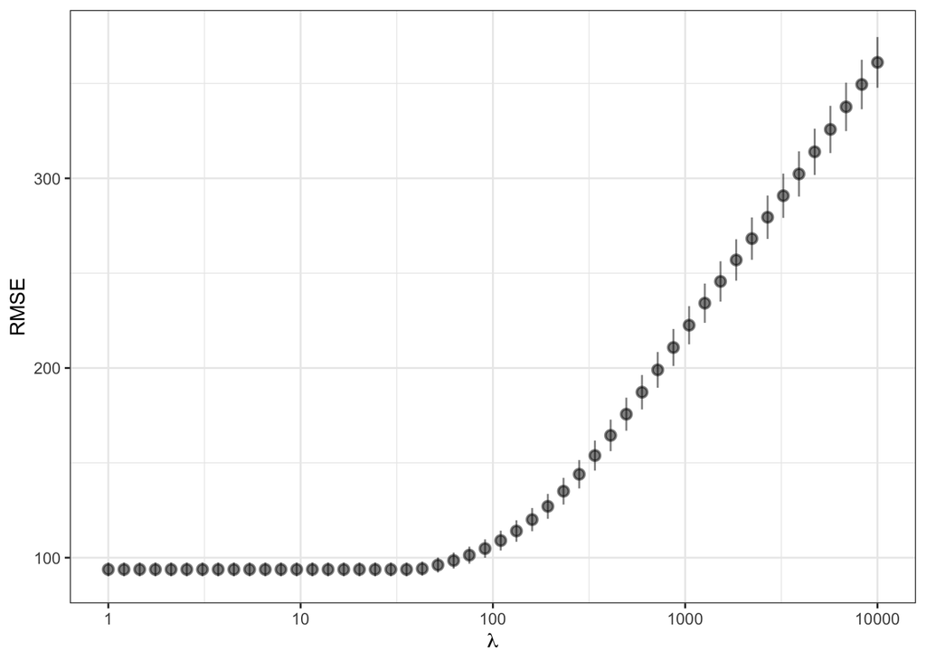

```r
ridge_tune_metrics <-
  ridge_tune |>
  collect_metrics()
ridge_tune_metrics |>
  filter(.metric == "rmse") |>
  ggplot(aes(
    x = penalty, y = mean,
    ymin = mean - std_err, ymax = mean + std_err
  )) +
  geom_pointrange(alpha = 0.5) +
  scale_x_log10() +
  labs(y = "RMSE", x = expression(lambda)) +
  theme_bw()
```

Although the grid we chose to tune the ridge model is adequate for the task, it is difficult to see which model(s) are best. If you are ever uncertain whether the grid is correct, it always makes sense to try other grid values.

A common case where you will want to redefine the grid is when the best fitting model lies on the edge of the grid of values and it seems that other models might do better. In that case, you must redefine the grid so it can consider potentially better-fitting models. In this example, the best fitting models *do* coincide with the edge of the grid, but it does not look like smaller penalties will lead to better fitting models—we’ve bottomed out.

Another common case is where you plan to use the 1SE rule to choose a best model, but the grid does not include models that are clearly worse than the lowest estimated test error (plus 1 SE). In the plot above, we have values of $\lambda$ corresponding with models that are expected to do much worse than the best fitting models, so we should be able to apply the 1SE rule without problems here.

Even though the grid is adequate for what we want to accomplish, let’s redefine it anyway so we can visualize the test errors more clearly, and you can see how easy it is to revisit past choices:

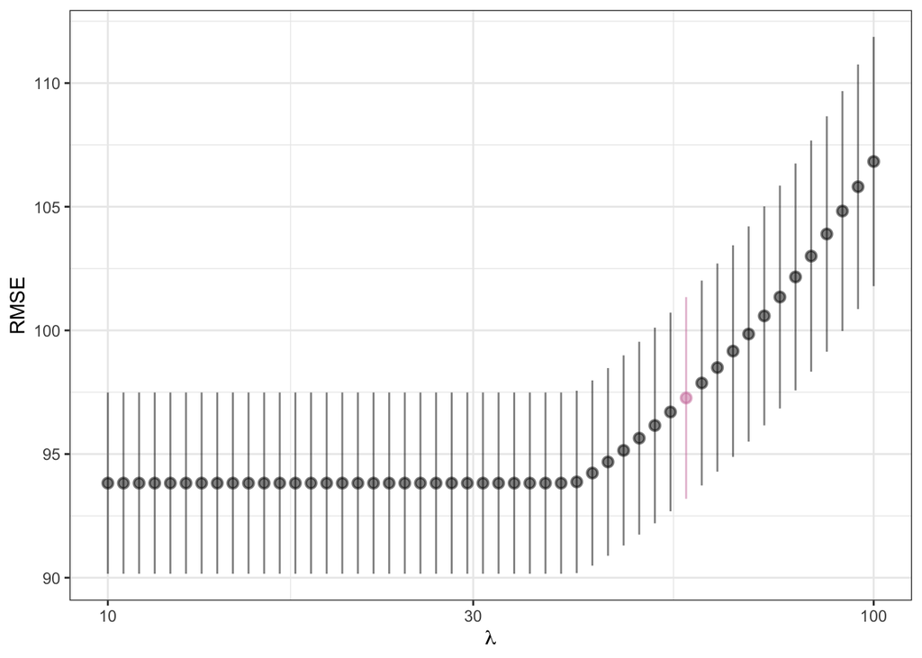

```r
ridge_tune_2 <-
  ridge_wf |>
  tune_grid(
    resamples = cv_folds,
    grid =
    # a new grid with narrower end points
      grid_regular(penalty(c(1, 2), trans = log10_trans()), levels = 50),
    metrics = metric_set(rmse, rsq_trad, mae)
  )
ridge_tune_2 |>
  collect_metrics() |>
  filter(.metric == "rmse") |>
  ggplot(aes(
    x = penalty, y = mean,
    ymin = mean - std_err, ymax = mean + std_err,
    colour = .config == "Preprocessor1_Model38"
  )) +
  geom_pointrange(alpha = 0.5, show.legend = FALSE) +
  scale_x_log10() +
  labs(y = "RMSE", x = expression(lambda)) +
  scale_colour_manual(values = c("black", "#CC79A7")) +
  theme_bw()
```

Based on these estimates, it appears the lowest possible test error lies somewhere between 90.2 and 97.5. So we will select the least complex model (i.e., greatest value of $\lambda$) among models with estimated test error within this range.

```r
ridge_1se_model <-
  ridge_tune_2 |>
  select_by_one_std_err(metric = "rmse", desc(penalty))
ridge_1se_model
```

```
## # A tibble: 1 × 2
##   penalty .config
##     <dbl> <chr>
## 1    56.9 Preprocessor1_Model38
```

The selected model is shown in the previous plot in color. Note that it is the simplest model with a test error estimate below the cutoff (can you see where the cutoff is?).

Now finalize the workflow for the ridge model:

```r
ridge_wf_tuned <-
  ridge_wf |>
  finalize_workflow(ridge_1se_model)
ridge_wf_tuned
```

```
## ══ Workflow ════════════════════════════════════════════════════════════════════
## Preprocessor: Recipe
## Model: linear_reg()
##
## ── Preprocessor ────────────────────────────────────────────────────────────────
## 4 Recipe Steps
##
## • step_dummy()
## • step_interact()
## • step_zv()
## • step_normalize()
##
## ── Model ───────────────────────────────────────────────────────────────────────
## Linear Regression Model Specification (regression)
##
## Main Arguments:
##   penalty = 56.898660290183
##   mixture = 0
##
## Computational engine: glmnet
```

## Selecting between lasso- and ridge-penalized linear regression

Now choose between the lasso and ridge models. First, fit each model to the full analysis set, predicting the target variable in the test set, and evaluate the resulting test error. This is done with the `last_fit()` function for each model.

```r
lasso_last_fit <-
  lasso_wf_tuned |>
  last_fit(Credit_split, metrics = metric_set(rmse, mae, rsq_trad))
ridge_last_fit <-
  ridge_wf_tuned |>
  last_fit(Credit_split, metrics = metric_set(rmse, mae, rsq_trad))
```

Extract model performance on the test set:

```r
lasso_test_metrics <-
  lasso_last_fit |>
  collect_metrics()
lasso_test_metrics
```

```
## # A tibble: 3 × 4
##   .metric  .estimator .estimate .config
##   <chr>    <chr>          <dbl> <chr>
## 1 rmse     standard      74.6   Preprocessor1_Model1
## 2 mae      standard      61.9   Preprocessor1_Model1
## 3 rsq_trad standard       0.968 Preprocessor1_Model1
```

```r
ridge_test_metrics <-
  ridge_last_fit |>
  collect_metrics()
ridge_test_metrics
```

```
## # A tibble: 3 × 4
##   .metric  .estimator .estimate .config
##   <chr>    <chr>          <dbl> <chr>
## 1 rmse     standard     106.    Preprocessor1_Model1
## 2 mae      standard      88.0   Preprocessor1_Model1
## 3 rsq_trad standard       0.937 Preprocessor1_Model1
```

Make a table combining the results:

```r
lasso_test_metrics <-
  lasso_test_metrics |>
  select(.metric, .estimate) |>
  mutate(model = "lasso")
ridge_test_metrics <-
  ridge_test_metrics |>
  select(.metric, .estimate) |>
  mutate(model = "ridge")
lasso_test_metrics |>
  bind_rows(ridge_test_metrics) |>
  pivot_wider(names_from = .metric, values_from = .estimate)
```

```
## # A tibble: 2 × 4
##   model  rmse   mae rsq_trad
##   <chr> <dbl> <dbl>    <dbl>
## 1 lasso  74.6  61.9    0.968
## 2 ridge 106.   88.0    0.937
```

Which of these is best? Are there differences in the values of the metrics that we should take note of? Do the metrics agree on the “best” model? In this case, there is a clear winner: the lasso model has lower RMSE and MAE, and higher $R^2$.

But a more important question is whether this level of performance is good enough in the business context. Of course, in this tutorial, the context is not clearly defined, but in practice it is extremely important.

Because the preferred model is a lasso regression, we can extract the non-zero coefficients from that model:

```r
lasso_last_fit |>
  extract_fit_parsnip() |>
  tidy() |>
  # only non-zero coefficients
  filter(estimate != 0) |>
  arrange(desc(abs(estimate))) |>
  print(n = 100)
```

```
## # A tibble: 22 × 3
##    term                                       estimate penalty
##    <chr>                                         <dbl>   <dbl>
##  1 (Intercept)                                 543.       2.33
##  2 Limit_x_Rating                              395.       2.33
##  3 Limit                                       291.       2.33
##  4 Income_x_Rating                            -209.       2.33
##  5 Income                                     -166.       2.33
##  6 Limit_x_Student_Yes                          89.6      2.33
##  7 Student_Yes                                  59.9      2.33
##  8 Rating                                       57.8      2.33
##  9 Income_x_Age                                -31.0      2.33
## 10 Cards                                        17.2      2.33
## 11 Income_x_Student_Yes                        -12.4      2.33
## 12 Limit_x_Cards                                 9.24     2.33
## 13 Age_x_Education                              -6.81     2.33
## 14 Income_x_Gender_Female                       -4.13     2.33
## 15 Income_x_Married_Yes                         -4.06     2.33
## 16 Age_x_Ethnicity_African.American             -3.81     2.33
## 17 Gender_Female_x_Ethnicity_African.American   -3.30     2.33
## 18 Cards_x_Gender_Female                         2.30     2.33
## 19 Cards_x_Student_Yes                           1.47     2.33
## 20 Gender_Female_x_Ethnicity_Asian              -1.45     2.33
## 21 Income_x_Ethnicity_African.American          -1.30     2.33
## 22 Education_x_Ethnicity_African.American       -0.200    2.33
```

From this, we can see some of the variables are relatively important, e.g. `Limit`, `Rating`, `Income`, and `Student`. We can visually examine how these variables relate to the quality of predictions.

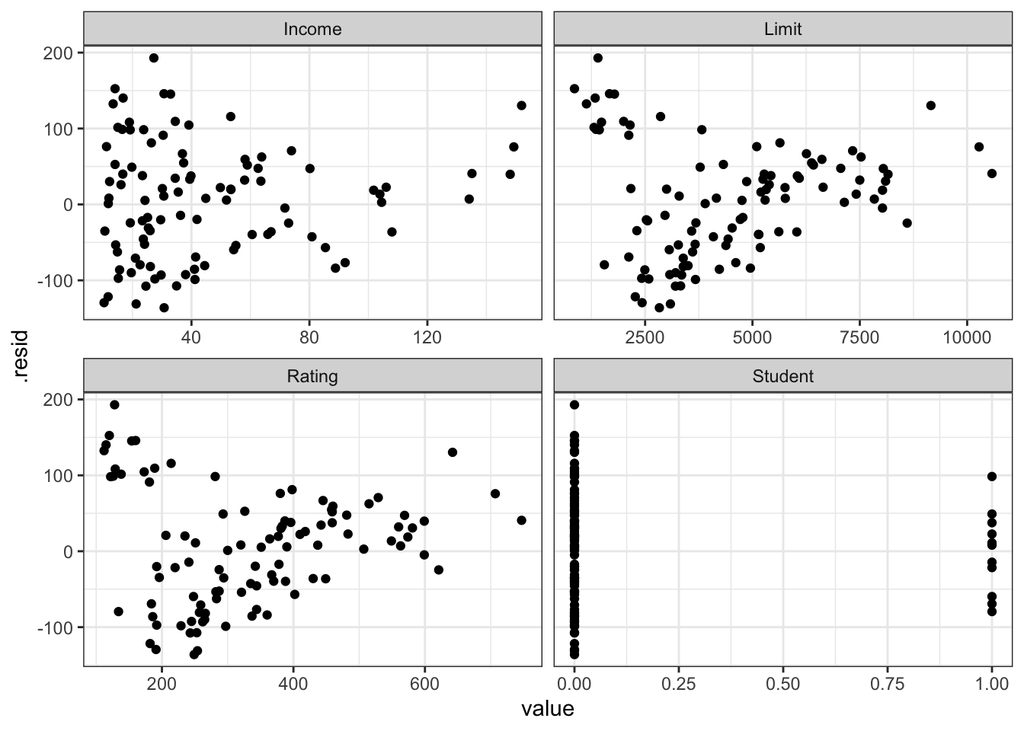

```r
lasso_last_fit |>
  # add predictions to the test set
  augment() |>
  transmute(Limit, Rating, Income,
    Student = 1L * (Student == "Yes"),
    .resid
  ) |>
  pivot_longer(c(-.resid)) |>
  ggplot(aes(x = value, y = .resid)) +
  geom_point() +
  facet_wrap(~name, scale = "free_x") +
  theme_bw()
```

A more thorough exploration of which observations the model predicts well and which it does not would be a natural next step in a real-world predictive task.

# Additional (optional) material

## Subset selection with leaps

Here we briefly discuss the **leaps** package. This is a useful and fast package that applies only to linear regression. The package interface however makes it a challenge to use. There are several other implementations for subset selection techniques that you can explore on your own. It is also quite feasible to program subset selection yourself, although (at least for linear regression) it will be slower than leaps, which uses an efficient algorithm.

```r
library(leaps)
```

### The **leaps** package

For linear regression models, the **leaps** package can perform best subset (`method = "exhaustive"`, the default), forward stepwise (`method = "forward"`) and backward stepwise (`method = "backward"`) selection efficiently. In all cases, you can specify the maximum size of the subsets to consider using `nvmax`.

#### Best subset linear regression

Perform best subset selection on the `Credit` data.

```r
best_subset_leaps <- regsubsets(Balance ~ .,
  data = Credit_train,
  method = "exhaustive", nvmax = 11
)
summary(best_subset_leaps)
```

```
## Subset selection object
## Call: regsubsets.formula(Balance ~ ., data = Credit_train, method = "exhaustive",
##     nvmax = 11)
## 11 Variables  (and intercept)
##                           Forced in Forced out
## Income                        FALSE      FALSE
## Limit                         FALSE      FALSE
## Rating                        FALSE      FALSE
## Cards                         FALSE      FALSE
## Age                           FALSE      FALSE
## Education                     FALSE      FALSE
## GenderFemale                  FALSE      FALSE
## StudentYes                    FALSE      FALSE
## MarriedYes                    FALSE      FALSE
## EthnicityAsian                FALSE      FALSE
## EthnicityAfrican American     FALSE      FALSE
## 1 subsets of each size up to 11
## Selection Algorithm: exhaustive
##           Income Limit Rating Cards Age Education GenderFemale StudentYes
## 1  ( 1 )  " "    " "   "*"    " "   " " " "       " "          " "
## 2  ( 1 )  "*"    " "   "*"    " "   " " " "       " "          " "
## 3  ( 1 )  "*"    " "   "*"    " "   " " " "       " "          "*"
## 4  ( 1 )  "*"    "*"   " "    "*"   " " " "       " "          "*"
## 5  ( 1 )  "*"    "*"   " "    "*"   "*" " "       " "          "*"
## 6  ( 1 )  "*"    "*"   "*"    "*"   "*" " "       " "          "*"
## 7  ( 1 )  "*"    "*"   "*"    "*"   "*" " "       "*"          "*"
## 8  ( 1 )  "*"    "*"   "*"    "*"   "*" " "       "*"          "*"
## 9  ( 1 )  "*"    "*"   "*"    "*"   "*" " "       "*"          "*"
## 10  ( 1 ) "*"    "*"   "*"    "*"   "*" "*"       "*"          "*"
## 11  ( 1 ) "*"    "*"   "*"    "*"   "*" "*"       "*"          "*"
##           MarriedYes EthnicityAsian EthnicityAfrican American
## 1  ( 1 )  " "        " "            " "
## 2  ( 1 )  " "        " "            " "
## 3  ( 1 )  " "        " "            " "
## 4  ( 1 )  " "        " "            " "
## 5  ( 1 )  " "        " "            " "
## 6  ( 1 )  " "        " "            " "
## 7  ( 1 )  " "        " "            " "
## 8  ( 1 )  "*"        " "            " "
## 9  ( 1 )  "*"        " "            "*"
## 10  ( 1 ) "*"        " "            "*"
## 11  ( 1 ) "*"        "*"            "*"
```

Each row in the output represents the best subset of a particular size. The `tidy()` function for the object `best_subset_leaps` summarizes each regression model and calculates fit statistics as well.

```r
tidy(best_subset_leaps)
```

```
## # A tibble: 11 × 16
##    `(Intercept)` Income Limit Rating Cards Age   Education GenderFemale
##    <lgl>         <lgl>  <lgl> <lgl>  <lgl> <lgl> <lgl>     <lgl>
##  1 TRUE          FALSE  FALSE TRUE   FALSE FALSE FALSE     FALSE
##  2 TRUE          TRUE   FALSE TRUE   FALSE FALSE FALSE     FALSE
##  3 TRUE          TRUE   FALSE TRUE   FALSE FALSE FALSE     FALSE
##  4 TRUE          TRUE   TRUE  FALSE  TRUE  FALSE FALSE     FALSE
##  5 TRUE          TRUE   TRUE  FALSE  TRUE  TRUE  FALSE     FALSE
##  6 TRUE          TRUE   TRUE  TRUE   TRUE  TRUE  FALSE     FALSE
##  7 TRUE          TRUE   TRUE  TRUE   TRUE  TRUE  FALSE     TRUE
##  8 TRUE          TRUE   TRUE  TRUE   TRUE  TRUE  FALSE     TRUE
##  9 TRUE          TRUE   TRUE  TRUE   TRUE  TRUE  FALSE     TRUE
## 10 TRUE          TRUE   TRUE  TRUE   TRUE  TRUE  TRUE      TRUE
## 11 TRUE          TRUE   TRUE  TRUE   TRUE  TRUE  TRUE      TRUE
## # ℹ 8 more variables: StudentYes <lgl>, MarriedYes <lgl>, EthnicityAsian <lgl>,
## #   `EthnicityAfrican American` <lgl>, r.squared <dbl>, adj.r.squared <dbl>,
## #   BIC <dbl>, mallows_cp <dbl>
```

Here is another view of the results:

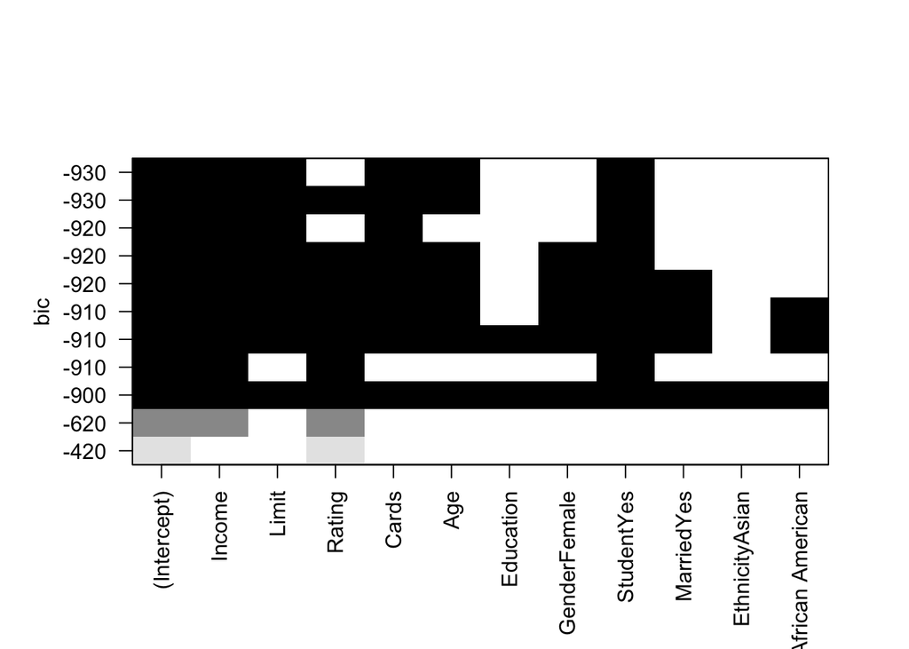

```r
plot(best_subset_leaps, scale = "bic")
```

In this plot, the models are ranked from lowest BIC (best) down to highest BIC (worst). `Rating` is the first variable selected.

#### Forward and backward stepwise linear regression

Perform forward and backward stepwise selection. This time, allow the search to include models with pairwise interactions.

```r
forward_leaps <- regsubsets(
  Balance ~
    (Income + Limit + Rating + Cards +
      Age + Education + Gender + Student +
      Married + Ethnicity):
    (Income + Limit + Rating + Cards +
      Age + Education + Gender + Student +
      Married + Ethnicity),
  data = Credit_train,
  method = "forward", nvmax = 65
)
backward_leaps <- regsubsets(
  Balance ~
    (Income + Limit + Rating + Cards +
      Age + Education + Gender + Student +
      Married + Ethnicity):
    (Income + Limit + Rating + Cards +
      Age + Education + Gender + Student +
      Married + Ethnicity),
  data = Credit_train,
  method = "backward", nvmax = 65
)
```

The results for the forward stepwise selection can be summarized as:

```r
tidy(forward_leaps)
```

```
## # A tibble: 65 × 70
##    `(Intercept)` Income Limit Rating Cards Age   Education GenderFemale
##    <lgl>         <lgl>  <lgl> <lgl>  <lgl> <lgl> <lgl>     <lgl>
##  1 TRUE          FALSE  FALSE TRUE   FALSE FALSE FALSE     FALSE
##  2 TRUE          TRUE   FALSE TRUE   FALSE FALSE FALSE     FALSE
##  3 TRUE          TRUE   FALSE TRUE   FALSE FALSE FALSE     FALSE
##  4 TRUE          TRUE   FALSE TRUE   FALSE FALSE FALSE     FALSE
##  5 TRUE          TRUE   FALSE TRUE   FALSE FALSE FALSE     FALSE
##  6 TRUE          TRUE   FALSE TRUE   FALSE FALSE FALSE     FALSE
##  7 TRUE          TRUE   FALSE TRUE   FALSE FALSE FALSE     FALSE
##  8 TRUE          TRUE   FALSE TRUE   TRUE  FALSE FALSE     FALSE
##  9 TRUE          TRUE   TRUE  TRUE   TRUE  FALSE FALSE     FALSE
## 10 TRUE          TRUE   TRUE  TRUE   TRUE  FALSE FALSE     FALSE
## # ℹ 55 more rows
## # ℹ 62 more variables: StudentYes <lgl>, MarriedYes <lgl>,
## #   EthnicityAsian <lgl>, `EthnicityAfrican American` <lgl>,
## #   `Income:Limit` <lgl>, `Income:Rating` <lgl>, `Income:Cards` <lgl>,
## #   `Income:Age` <lgl>, `Income:Education` <lgl>, `Income:GenderFemale` <lgl>,
## #   `Income:StudentYes` <lgl>, `Income:MarriedYes` <lgl>,
## #   `Income:EthnicityAsian` <lgl>, `Income:EthnicityAfrican American` <lgl>, …
```

Again, `Rating` is the first variable added to the model.

Here are the results for backward selection:

```r
tidy(backward_leaps) |>
  arrange(desc(row_number()))
```

```
## # A tibble: 65 × 70
##    `(Intercept)` Income Limit Rating Cards Age   Education GenderFemale
##    <lgl>         <lgl>  <lgl> <lgl>  <lgl> <lgl> <lgl>     <lgl>
##  1 TRUE          TRUE   TRUE  TRUE   TRUE  TRUE  TRUE      TRUE
##  2 TRUE          TRUE   TRUE  TRUE   TRUE  FALSE TRUE      TRUE
##  3 TRUE          TRUE   TRUE  TRUE   TRUE  FALSE TRUE      TRUE
##  4 TRUE          TRUE   TRUE  TRUE   TRUE  FALSE TRUE      TRUE
##  5 TRUE          TRUE   TRUE  TRUE   TRUE  FALSE TRUE      TRUE
##  6 TRUE          TRUE   TRUE  TRUE   TRUE  FALSE TRUE      TRUE
##  7 TRUE          TRUE   TRUE  TRUE   TRUE  FALSE TRUE      TRUE
##  8 TRUE          TRUE   TRUE  TRUE   TRUE  FALSE TRUE      TRUE
##  9 TRUE          TRUE   TRUE  TRUE   TRUE  FALSE TRUE      TRUE
## 10 TRUE          TRUE   TRUE  TRUE   TRUE  FALSE TRUE      TRUE
## # ℹ 55 more rows
## # ℹ 62 more variables: StudentYes <lgl>, MarriedYes <lgl>,
## #   EthnicityAsian <lgl>, `EthnicityAfrican American` <lgl>,
## #   `Income:Limit` <lgl>, `Income:Rating` <lgl>, `Income:Cards` <lgl>,
## #   `Income:Age` <lgl>, `Income:Education` <lgl>, `Income:GenderFemale` <lgl>,
## #   `Income:StudentYes` <lgl>, `Income:MarriedYes` <lgl>,
## #   `Income:EthnicityAsian` <lgl>, `Income:EthnicityAfrican American` <lgl>, …
```

### Selecting the best subset

We have generated subsets using best subsets and forward and backward stepwise selection, using the training data. The next step is to use our test set to select the best subset from among the candidates. (We could also start over and redesign the model assessment strategy.)

This will require some manual programming, since these methods are not integrated into tidymodels yet. You can consult Section 6.5 in ISLR2 for examples of how to proceed. It is left as an exercise for the interested student to program this on their own.

Note that **leaps** is extremely fast because it makes use of the updating formula which is available for linear regression. But it only works for linear regression.